# Two Sample Hypothesis Tests

## Comparing Means with Independent Samples

Structure of Two-Sample Hypothesis Tests

### Setting Up Hypotheses

Let $\theta_1$ and $\theta_2$ be the parameters of interest from populations 1 and 2, respectively.

**1. Interested in whether $\theta_1 > \theta_2$:**
$$\begin{aligned}
H_0\!:~ & \theta_1 = \theta_2 \\
H_a\!:~ & \theta_1 > \theta_2 \\
\text{Equivalent:} \quad & H_0\!:~ \theta_1 - \theta_2 = 0 \qquad
H_a\!:~ \theta_1 - \theta_2 > 0
\end{aligned}$$

**2. Interested in whether $\theta_1 < \theta_2$:**
$$\begin{aligned}
H_0\!:~ & \theta_1 = \theta_2 \\
H_a\!:~ & \theta_1 < \theta_2 \\
\text{Equivalent:} \quad & H_0\!:~ \theta_1 - \theta_2 = 0 \qquad
H_a\!:~ \theta_1 - \theta_2 < 0
\end{aligned}$$

**3. Interested in whether $\theta_1 \ne \theta_2$:**
$$\begin{aligned}
H_0\!:~ & \theta_1 = \theta_2 \\
H_a\!:~ & \theta_1 \ne \theta_2 \\
\text{Equivalent:} \quad & H_0\!:~ \theta_1 - \theta_2 = 0 \qquad
H_a\!:~ \theta_1 - \theta_2 \ne 0
\end{aligned}$$

### Structure of a Test Statistic

The general structure of a test statistic is:
$$\text{test statistic} = \frac{\text{(observed
statistic)} - \text{(hypothesized value)}}{\text{standard
error}}$$

**Common Cases:**

- $\sigma$ known: $z = \dfrac{\bar{x} - \mu_0}{\sigma / \sqrt{n}}$
- $\sigma$ unknown: $t = \dfrac{\bar{x} - \mu_0}{s / \sqrt{n}}$
- Proportions: $z = \dfrac{\hat{p} - p_0}{\sqrt{p_0(1 - p_0)/n}}$

## Hypothesis Test on a Difference of Means ($\mu_1 - \mu_2$)

- When $\sigma_1$ and $\sigma_2$ are known:

$$\begin{aligned}
H_0&: \mu_1 - \mu_2 = 0 \\
H_a&: \mu_1 - \mu_2 > 0 \quad \text{(or } < 0 \text{, } \ne 0
\text{)}
\end{aligned}$$

**Test Statistic:**
$$z =
\frac{(\bar{x}_1 - \bar{x}_2) - 0}{\sqrt{\frac{\sigma_1^2}{n_1} +
\frac{\sigma_2^2}{n_2}}}$$

Reference distribution: standard normal (Z distribution).

*Note: This scenario is rare in practice since both population standard deviations $\sigma_1$ and $\sigma_2$ are seldom known.*

- When $\sigma_1$ and $\sigma_2$ are unknown:

**Case 1: Assume equal variances $\sigma_1^2 = \sigma_2^2$**
$$\begin{aligned}
H_0&: \mu_1 - \mu_2 = 0 \\
H_a&: \mu_1 - \mu_2 > 0 \quad \text{(or } < 0 \text{, } \ne 0
\text{)}
\end{aligned}$$

**Test Statistic:**
$$t =
\frac{(\bar{x}_1 - \bar{x}_2) - 0}{s_p \sqrt{\frac{1}{n_1} +
\frac{1}{n_2}}}$$

where the pooled standard deviation is defined as:
$$s_p^2 = \frac{(n_1 - 1)s_1^2 + (n_2 -
1)s_2^2}{n_1 + n_2 - 2}$$

Reference distribution: $t$-distribution with $n_1 + n_2 - 2$ degrees of freedom.

(Use this only when equal variances can reasonably be assumed.)

**Case 2: Assume Unequal Variances $\sigma_1^2 \ne \sigma_2^2$ (Welch’s t-test)**
$$\begin{aligned}
H_0 &: \mu_1 - \mu_2 = 0 \\
H_a &: \mu_1 - \mu_2 > 0 \quad (\text{or } < 0,\ \ne 0)
\end{aligned}$$

**Test Statistic:**
$$t^* =
\frac{(\bar{x}_1 - \bar{x}_2) - 0}{\sqrt{\frac{s_1^2}{n_1} +
\frac{s_2^2}{n_2}}}$$

Reference distribution: approximately a $t$-distribution.

*Degrees of freedom (by hand):*
$$\min(n_1 - 1,\ n_2 - 1)$$

*Note:* R uses a more sophisticated approximation for degrees of freedom in this case.

## Comparing Means of Independent Samples (Normal Population Assumptions)

We should check the assumption that the underlying populations of individual responses are each Normally distributed. Nearly Normal Condition:

- We must check this for both groups; a violation for either one violates the condition.
- The Normality assumption matters most when sample sizes are very small.
- For $n < 10$ in either group, this method should not be used if the histogram or Normality plots show clear skewness.
- For $n$’s of 10 or so, a moderately skewed histogram is okay. But, for strongly skewed data or data containing outliers this method should be avoided.
- For larger samples $n \geq 20$, data skewness is less of an issue — but, we still need to check if there are any outliers in the data, extreme skewness, and multiple modes.

### Comparing Two Populations Means: Independent Sampling (Equal Variances Assumed)

Consider two independent populations with unknown means $\mu_1$ and $\mu_2$, and unknown standard deviations $\sigma_1$ and $\sigma_2$ ($\sigma_1 = \sigma_2$), respectively. We can make an inference about their mean difference $\mu_1 - \mu_2$ by using the difference between their point estimates (sample means): $\bar{Y}_1 - \bar{Y}_2$. When the assumptions and conditions are met,

$$\frac{(\bar{Y}_1 - \bar{Y}_2) - (\mu_1 -
\mu_2)}{S_p \sqrt{\frac{1}{n_1} + \frac{1}{n_2}}}
= \frac{(\bar{Y}_1 - \bar{Y}_2) - (\mu_1 - \mu_2)}{\sqrt{S_p^2
\left[\frac{1}{n_1} + \frac{1}{n_2} \right] }},$$

can be modelled by a $t(\nu)$ distribution; where $\nu = n_1 + n_2 - 2$ and

$$S_p^2 = \frac{(n_1 - 1)s_1^2 + (n_2 -
1)s_2^2}{n_1 + n_2 - 2}.$$

**Conditions Required for Valid Inference about $\mu_1 - \mu_2$:**

1. The two samples are randomly selected in an independent manner from the two target populations.
2. Both sampled populations have distributions that are approximately Normal.
3. The population variances are equal (e.g., $\sigma_1 = \sigma_2$).

### Small-Sample Confidence Interval for $\mu_1 - \mu_2$ (with equal variances)

**Parameter:** $\mu_1 - \mu_2$

**Confidence interval** ($\nu = \text{df}$):

$$(\bar{Y}_1 - \bar{Y}_2) \pm
t_{\alpha/2}(\nu) S_p \sqrt{\frac{1}{n_1} + \frac{1}{n_2}},$$

where $\nu = n_1 + n_2 - 2$ and
$$S_p^2 = \frac{(n_1 - 1)s_1^2 + (n_2 -
1)s_2^2}{n_1 + n_2 - 2}$$

(requires that Normal samples are independent and the assumption that $\sigma_1^2 = \sigma_2^2$). The critical value $t_{\alpha/2}(\nu)$ depends on the particular confidence level and the number of degrees of freedom.

Comparing Two Population Means Managerial Success Indexes for Two Groups (With Equal Variances Assumed)

Behavioural researchers have developed an index designed to measure managerial success. The index (measured on a 100-point scale) is based on the manager’s length of time in the organization and their level within the term; the higher the index, the more successful the manager. Suppose a researcher wants to compare the average index for the two groups of managers at a large manufacturing plant. Managers in group 1 engage in **high volume of interactions** with people outside the managers’ work unit (such interaction include phone and face-to-face meetings with customers and suppliers, outside meetings, and public relation work). Managers in group 2 **rarely interact** with people outside their work unit. Independent random samples of 12 and 15 managers are selected from groups 1 and 2, respectively, and success index of each is recorded.

**Response variable:** Managerial Success Indexes (quantitative, continuous, 0–100 scale)

**Explanatory variable:** Type of group (nominal categorical: *Group 1 = interaction with outsiders*, *Group 2 = fewer interactions*)

**R Code**

```
# Importing data file into R
success = read.csv(file = "success.csv", header = TRUE);

# Getting names of variables
names(success);

# Seeing first few observations
head(success);

# Attaching data file
attach(success);
```

**R Code**

```
## [1] "Success_Index" "Group"
##   Success_Index Group
## 1            65     1
## 2            66     1
## 3            58     1
## 4            70     1
## 5            78     1
## 6            53     1
```

**R code (Descriptive Statistics)**

```
# loading library mosaic
library(mosaic)

favstats(Success_Index ~ Group)
```

**R Code (Descriptive Statistics)**

```
## .group min   Q1 median   Q3 max     mean       sd  n
##       1  53 62.25  65.50 69.25  78 65.33333 6.610368 12
##       2  34 42.50  50.00 54.50  68 49.46667 9.334014 15
```

**R Code (Descriptive Statistics)**

```
summary(Success_Index[Group == 1]);
length(Success_Index[Group == 1]);
sd(Success_Index[Group == 1]);

summary(Success_Index[Group == 2]);
length(Success_Index[Group == 2]);
sd(Success_Index[Group == 2]);
```

Note: Group 1 = “interaction with outsiders” and Group 2 = “fewer interactions”.

**R Output**

```
##  Min.  1st Qu.  Median    Mean  3rd Qu.    Max.
##  53.00   62.25   65.50   65.33   69.25   78.00
## [1] 12
## [1] 6.610368

##  Min.  1st Qu.  Median    Mean  3rd Qu.    Max.
##  34.00   42.50   50.00   49.47   54.50   68.00
## [1] 15
## [1] 9.334014
```

**Nearly Normal Condition (Group 1: “interaction with outsiders”):**

```
stem(Success_Index[Group == 1]);
```

**R Output**

```
##
##  The decimal point is 1 digit(s) to the right of the |
##
##  5 | 38
##  6 | 0335689
##  7 | 018
```

**Nearly Normal Condition (Group 2: “fewer interactions”):**

```
stem(Success_Index[Group == 2]);
```

**R Output**

```
##
##  The decimal point is 1 digit(s) to the right of the |
##
##  3 | 46
##  4 | 22368
##  5 | 023367
##  6 | 28
```

**Nearly Normal Condition (Group 1: “interaction with outsiders”):**

```
qqnorm(Success_Index[Group == 1]);
qqline(Success_Index[Group == 1]);
```

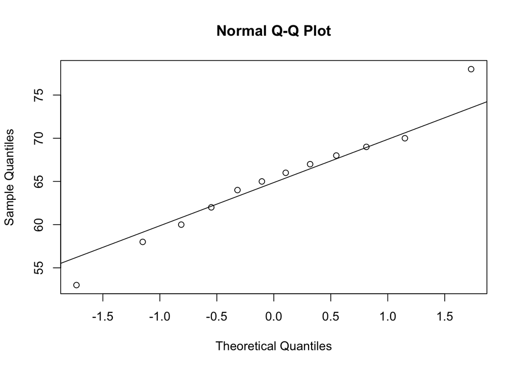

Q-Q Plot for Group 1: Interaction with Outsiders

**Nearly Normal Condition (Group 2: “fewer interactions”):**

```
qqnorm(Success_Index[Group == 2]);
qqline(Success_Index[Group == 2]);
```

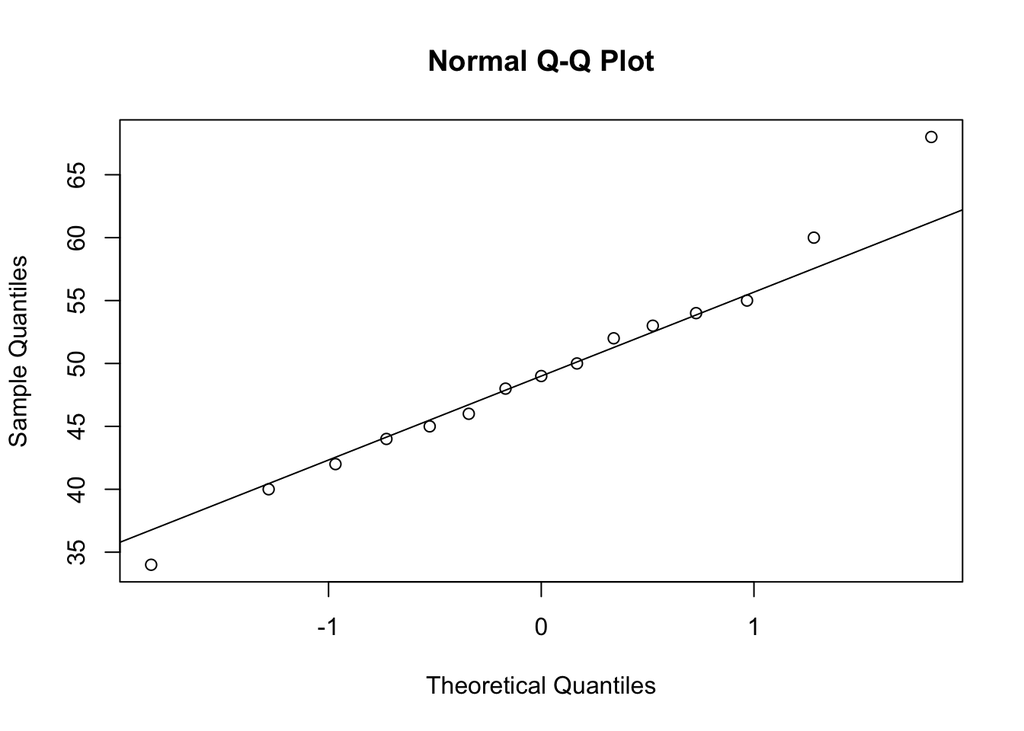

Q-Q Plot for Group 2: Fewer Interactions

**Nearly Normal Condition:**

```
boxplot(Success_Index ~ Group, col = c("red", "blue"))
```

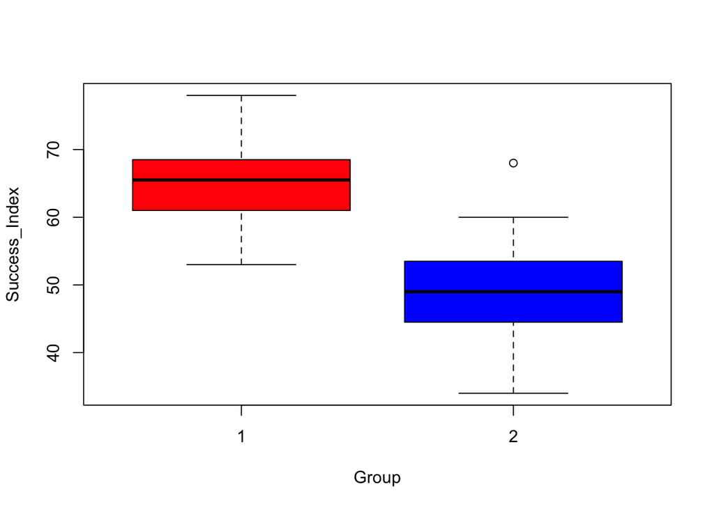

Boxplot of Success Index by Group

**Boxplot with `ggplot2`:**

```
# loading library;
library(ggplot2);

# converting a numeric variable into factor (categorical data)
group <- factor(Group);

# bp: just a name (not code) to store boxplots;
bp <- ggplot(success,
             aes(x = group, y = Success_Index, fill = group));

our.labs <- c("Interaction with Outsiders", "Fewer Interactions");

bp +
  geom_boxplot() +
  scale_x_discrete(labels = our.labs);
```

[figure not shown]

Boxplot of Success Index by Group using ggplot2

**Checking the Assumptions and Conditions**

**Independent Group Assumption:** The success index in group 1 is unrelated to the success index in group 2.

**Randomization Condition:** The 27 managers were randomly and independently selected (12 for group 1, and 15 for group 2).

**Nearly Normal Condition:** The two boxplots of success indexes do not show skewness; the two stemplots/histograms of success indexes are unimodal, fairly symmetric and approximately bell-shaped. Q–Q plots also suggest the normality assumption is reasonable.

**Equal Variances Assumption:** The two boxplots of success indexes appear to have the same spread; thus, the samples appear to have come from populations with approximately the same variance.

Since the conditions are satisfied, it is appropriate to construct a $t$ confidence interval with  
$df = 12 + 15 - 2 = 25$.  
**From the data, the following statistics were calculated:**

$$\begin{aligned}
n_1 &= 12 &\quad n_2 &= 15 \\
\bar{x}_1 &= 65.33 &\quad \bar{x}_2 &= 49.47 \\
s_1^2 &= 6.61^2 &\quad s_2^2 &= 9.33^2
\end{aligned}$$

**The pooled variance estimator is:**

$$s_p^2 = \frac{(n_1 - 1)s_1^2 + (n_2 -
1)s_2^2}{n_1 + n_2 - 2}
= \frac{(12 - 1)(6.61^2) + (15 - 1)(9.33^2)}{12 + 15 - 2}
= 67.97$$

**The number of degrees of freedom is:**
$$\nu = n_1 + n_2 - 2 = 12 + 15 - 2 =
25$$

**Two-sample t-test (Student’s t-test) for the Difference Between Means $\mu_1 - \mu_2$:**

Is there evidence to suggest that the mean success index differs between the two groups?

**1. State Hypotheses:**
$$\begin{aligned}
H_0 &: \mu_1 = \mu_2 \quad \text{or} \quad H_0 : \mu_1 - \mu_2 = 0
\\
H_a &: \mu_1 \ne \mu_2 \quad \text{or} \quad H_a : \mu_1 - \mu_2 \ne
0
\end{aligned}$$

**2. Test Statistic:**
$$t^*
= \frac{\bar{x}_1 - \bar{x}_2}{\sqrt{\frac{s_p^2}{n_1} +
\frac{s_p^2}{n_2}}}
= \frac{65.33 - 49.47}{\sqrt{\frac{67.97}{12} + \frac{67.97}{15}}}
= 4.97$$

**3. P-value:**

Using table:
$$\text{df} = 25 \quad
\Rightarrow \quad \text{P-value} < 2(0.005)$$

Using R:

```
# One way:
2*(1 - pt(4.97, df = 25));

# Another way:
2 * pt(4.97, df = 25, lower.tail = FALSE);
```

Both methods return:
$$\text{P-value}
\approx 4.03 \times 10^{-5}$$
**4. Conclusion.**

Since the P-value is very small, we have strong evidence to indicate that there is a difference in mean success index between group 1 and group 2.

**Note.** As a follow-up, we could find a 95% CI for $\mu_1 - \mu_2$ to estimate this difference. Then, we could provide an estimate of how much higher the mean success index for group 1 is. ::::::::::::::::::::

### Comparing Two Populations Means: Independent Sampling (Unequal Variances Assumed)

### Small-Sample Confidence Interval for $\mu_1 - \mu_2$ (Unequal Variances)

Draw an SRS of size $n_1$ from a Normal population with unknown mean $\mu_1$, and draw an independent SRS of size $n_2$ from another Normal population with unknown mean $\mu_2$. A confidence interval for $\mu_1 - \mu_2$ is given by

$$(\bar{x}_1 - \bar{x}_2) \pm t^*
\sqrt{\frac{s_1^2}{n_1} + \frac{s_2^2}{n_2}}$$

Here $t^*$ is the critical value for the $t(k)$ density curve with area $C$ between $-t^*$ and $t^*$. The degrees of freedom $k$ are equal to the smaller of $n_1 - 1$ and $n_2 - 1$.

### Degrees of Freedom

*Option 1.* With software, use the statistic $t$ with accurate critical values from the approximating $t$ distribution.

The distribution of the two-sample $t$ statistic is very close to the $t$ distribution with degrees of freedom $df$ given by

$$df = \frac{\left( \frac{s_1^2}{n_1} +
\frac{s_2^2}{n_2} \right)^2}
{
\left( \frac{1}{n_1 - 1} \left( \frac{s_1^2}{n_1} \right)^2 \right)
+
\left( \frac{1}{n_2 - 1} \left( \frac{s_2^2}{n_2} \right)^2 \right)
}$$

This approximation is accurate when both sample sizes $n_1$ and $n_2$ are 5 or larger.

*Option 2.* Without software, use the statistic $t$ with critical values from the $t$ distribution with degrees of freedom equal to the smaller of $n_1 - 1$ and $n_2 - 1$. These procedures are always conservative for any two Normal populations.

### Two-Sample t-Test (Unequal Variances)

To test the hypothesis $H_0 : \mu_1 = \mu_2$, calculate the two-sample $t$ statistic:

$$t^* = \frac{\bar{x}_1 -
\bar{x}_2}{\sqrt{\frac{s_1^2}{n_1} + \frac{s_2^2}{n_2}}}$$

and use $P$-values or critical values for the $t(k)$ distribution.

“Conservationists have despaired over destruction of tropical rain forest by logging, clearing, and burning”. These words begin a report on a statistical study of the effects of logging in Borneo. Here are data on the number of tree species in 12 unlogged forest plots and 9 similar plots logged 8 years earlier:

Unlogged: 22 18 22 20 15 21 13 13 19 13 19 15  
Logged : 17 4 18 14 18 15 15 10 12

Does logging significantly reduce the mean number of species in a plot after 8 years? State the hypotheses and do a t test. Is the result significant at the 5% level?  
**Solution:**  
1. State hypotheses. $H_0: \mu_1 = \mu_2$ vs. $H_a: \mu_1 > \mu_2$, where $\mu_1$ is the mean number of species in unlogged plots and $\mu_2$ is the mean number of species in plots logged 8 years earlier.

2. Test statistic.
$$t^* \;=\;\frac{\bar
x_1 - \bar x_2}{\sqrt{s_1^2/n_1 + s_2^2/n_2}}
\;=\;2.1140$$
$$(\bar x_1 =
17.5,\;\bar x_2 = 13.6666,\;s_1 = 3.5290,\;s_2 = 4.5,\;n_1 = 12,\;n_2 =
9)$$

3. P-value. Using Table, we have $df = 8$, and $0.025 < \text{P-value} < 0.05$.

4. Conclusion. Since P-value $< 0.05$, we reject $H_0$. There is strong evidence that the mean number of species in unlogged plots is greater than that for logged plots 8 years after logging.

A company that sells educational materials reports statistical studies to convince customers that its materials improve learning. One new product supplies “directed reading activities” for classroom use. These activities should improve the reading ability of elementary school pupils.

A consultant arranges for a third-grade class of 21 students to take part in these activities for an eight-week period. A control classroom of 23 third-graders follows the same curriculum without the activities. At the end of the eight weeks, all students are given a Degree of Reading Power (DRP) test, which measures the aspects of reading ability that the treatment is designed to improve. The data appear in the following table.

| **Treatment** |  |  |  | **Control** |  |  |  |
| --- | --- | --- | --- | --- | --- | --- | --- |
| 24 | 61 | 59 | 46 | 42 | 33 | 46 | 37 |
| 43 | 44 | 52 | 43 | 43 | 41 | 10 | 42 |
| 58 | 67 | 62 | 57 | 55 | 19 | 17 | 55 |
| 71 | 49 | 54 |  | 26 | 54 | 60 | 28 |
| 43 | 53 | 57 |  | 62 | 20 | 53 | 48 |
| 49 | 56 | 33 |  | 37 | 85 | 42 |  |

Because we hope to show that the treatment (Group 1) is better than the control (Group 2), the hypotheses are:

$$H_0 : \mu_1 = \mu_2$$
$$H_a : \mu_1 > \mu_2$$

```
# Step 1. Entering data
treatment = c(24, 61, 59, 46, 43, 44, 52, 43, 58, 67, 62, 57,
              71, 49, 54, 43, 53, 57, 49, 56, 33);
control = c(42, 33, 46, 37, 43, 41, 10, 42, 55, 19, 17, 55,
            26, 54, 60, 28, 62, 20, 53, 48, 37, 85, 42);
```

**Nearly Normal Condition (treatment):**

```
# Making stemplot;

stem(treatment);
```

```
##
## The decimal point is 1 digit(s) to the right of the |
##
## 2 | 4
## 3 | 3
## 4 | 3334699
## 5 | 23467789
## 6 | 127
## 7 | 1
```

**Nearly Normal Condition (control):**

```
# Making stemplot;

stem(control);
```

```
##
## The decimal point is 1 digit(s) to the right of the |
##
## 0 | 079
## 2 | 068377
## 4 | 12223683455
## 6 | 02
## 8 | 5
```

**Nearly Normal Condition (treatment):**

```
# Making Q-Q plot;
qqnorm(treatment, pch=19, col="red", main="Treatment");
qqline(treatment, lty=2);
```

[figure not shown]

Q-Q Plot for Treatment Group

**Nearly Normal Condition (control):**

```
# Making Q-Q plot;
qqnorm(treatment, pch=19, col="red", main="Control");
qqline(control, lty=2);
```

[figure not shown]

Stemplots suggest that there is a mild outlier in the control group but no deviation from Normality serious enough to prevent us from using t procedures. Normal Q-Q plots for both groups confirm that both are roughly Normal. The summary statistics are:

```
summary(treatment);

## Min. 1st Qu.  Median    Mean 3rd Qu.    Max.
## 24.00   44.00   53.00   51.48   58.00   71.00

summary(control);

## Min. 1st Qu.  Median    Mean 3rd Qu.    Max.
## 10.00   30.50   42.00   41.52   53.50   85.00
```

```
# Step 1. Entering data;

treatment = c(24, 61, 59, 46, 43, 44, 52, 43, 58, 67, 62, 57,
              71, 49, 54, 43, 53, 57, 49, 56, 33);

control = c(42, 33, 46, 37, 43, 41, 10, 42, 55, 19, 17, 55,
            26, 54, 60, 28, 62, 20, 53, 48, 37, 85, 42);

# Step 2. Hypothesis Test

t.test(treatment, control, alternative="greater")
```

**HT (using R)**

```
##
##  Welch Two Sample t-test
##
## data:  treatment and control
## t = 2.3106, df = 37.855, p-value = 0.01305
## alternative hypothesis: true difference in means is greater than 0
## 95 percent confidence interval:
##  2.333784      Inf
## sample estimates:
## mean of x mean of y
##    51.47619 41.52174
```

**HT (using table)**

```
round (mean(treatment) ,2);

##[1] 51.48

round (sd(treatment) ,2);

##[1] 11.01

round (mean(control) ,2);

##[1] 41.52

round (sd(control) ,2);

##[1] 17.15
```

Test statistic.
$$t^* = \frac{\bar{x}_1 -
\bar{x}_2}{\sqrt{\frac{s_1^2}{n_1} + \frac{s_2^2}{n_2}}} = 2.31$$
$$\quad
(\bar{x}_1 = 51.48, \, \bar{x}_2 = 41.52, \, s_1 = 11.01, \, s_2 =
17.15,
\quad n_1 = 21 \text{ and } n_2 = 23)$$

The conservative approach uses the *t*(20) distribution. The P-value for the one-sided test is
$$\text{P-value} = P\bigl(T \geq 2.31
\bigr)$$
Comparing $t = 2.31$ with the entries in Table 5 for 20 degrees of freedom, we see that
$$0.01 < \text{P-value} < 0.025.$$

Since our P-value is “small”, we reject the null hypothesis (Note that we would reject $H_0$ at the 2.5% significance level). The data strongly suggest that directed reading activity improves the DRP score.

The design of the DRP study is not ideal. Random assignment of students was not possible in a school environment, so existing third-grade classes were used. The effect of the reading programs is therefore confounded with any other differences between the two classes. The classes were chosen to be as similar as possible in variables such as the social and economic status of the students. Pretesting showed that the two classes were on the average quite similar in reading ability at the beginning of the experiment. To avoid the effect of two different teachers, the same teacher taught reading in both classes during the eight-week period of the experiment. We can therefore be somewhat confident that our two-sample procedure is detecting the effect of the treatment and not some other difference between the classes. ::::::::::::::::

**Why do we use hypothesis tests?**

To conduct tests on parameters and to quantify the degree of certainty with probability.

The smaller the p-value, the stronger the evidence against $H_0$ (provided assumptions are met).

**Understanding Significance Levels**

Suppose you have the following limited information:

- A test was statistically significant at the 5% level.

We **cannot** make this conclusion for certain. That is,
$$p\text{-value} < 0.05 \quad
\not\Rightarrow \quad p\text{-value} < 0.01.$$

- A test was statistically significant at the 1% level.

Yes! Because
$$p\text{-value} < 0.01
< 0.05.$$

## The Fold Rule

A rule which can be used to quickly determine whether population variances are equal or unequal using sample variances.

*Note: only a rule*

If
$$\frac{\max(s_1, s_2)}{\min(s_1, s_2)}
< \sqrt{2}
\quad \text{then we can consider } \sigma_1^2 = \sigma_2^2$$

and

$$\frac{\max(s_1^2, s_2^2)}{\min(s_1^2,
s_2^2)} < 2
\quad \text{then we can consider } \sigma_1^2 = \sigma_2^2$$

**Note:** rather crude technique.

Hypothesis tests for equality of two variances do exist:

$$H_0: \sigma_1^2 = \sigma_2^2 \quad
\text{vs} \quad H_a: \sigma_1^2 \neq \sigma_2^2$$

## Two Sample Hypothesis Test on Paired Data

When observations in sample 1 matches with an observation in sample 2. Observations in sample 1 are, usually, highly, correlated with observations in sample 2, these data are often called matched pairs. For each pair (the same cases), we form: Difference = observation in sample 2 - observation in sample 1. Thus, we have one single sample of differences scores. For example, in longitudinal studies: Pre- and post-survey of attitudes towards statistics (Same student is measured twice: Time 1 (pre) and Time 2 (post). We measure change in the attitudes: Post - Pre (for each student). Often these types of studies are called, repeated measures.  
Paired Data Condition: the data must be quantitative and paired.  
Independence Assumption:

- If the data are p aired, the groups are not independent. For this methods, it is the differences that must be independent of each other.
- The pairs may be a random sample.
- In experimental design, the order of the two treatments may be randomly assigned, or the treatments ma y be randomly assigned to one member of each pair.
- In a before-and-after study, we may believe that the observed differences are representative sample of a population of interest. If there is any doubt, we need to include a control group to be able to draw conclusions.
- If samples are bigger than 10 % of the target population, we need to acknowledge this and note in our report. When we sample from a ﬁnite population, we should be careful not to sample more than 10 % of that population. Sampling too large a fraction of the population calls the independence assumption into question.

Recall chapter 10 when we first introduced paired data, now we are going to use it again:

| Sample Units | Measurement 1 (*M*<sub>1</sub>) | Measurement 2 (*M*<sub>2</sub>) | Difference (*M*<sub>2</sub> − *M*<sub>1</sub> or *M*<sub>1</sub> − *M*<sub>2</sub>) |
| --- | --- | --- | --- |
| 1 | *x*<sub>11</sub> | *x*<sub>12</sub> | *x*<sub>*d*1</sub> = *x*<sub>12</sub> − *x*<sub>11</sub> |
| 2 | *x*<sub>21</sub> | *x*<sub>22</sub> | *x*<sub>*d*2</sub> = *x*<sub>22</sub> − *x*<sub>21</sub> |
| 3 | *x*<sub>31</sub> | *x*<sub>32</sub> | *x*<sub>*d*2</sub> = *x*<sub>32</sub> − *x*<sub>31</sub> |
| …… |  |  |  |
| n | *x*<sub>*n*1</sub> | *x*<sub>*n*2</sub> | *x*<sub>*d**n*</sub> = *x*<sub>*n*2</sub> − *x*<sub>*n*1</sub> |

A table of paired data

From that table, we can get $\bar{X_d}$, which is the mean, variance and standard deviation of the difference. We need these values to continue our analysis.  
**Step 1: Stating the Structure of Testing Hypothesis**

The idea of two sample hypothesis test on pair data is transforming it to one sample hypothesis data, so that our analysis based on $\mu_d$.

| Cases | Null Hypothesis | Alternative Hypothesis |
| --- | --- | --- |
| 1 | *μ*<sub>*d*</sub> = 0 | *μ*<sub>*d*</sub> > 0 |
| 2 | *μ*<sub>*d*</sub> = 0 | *μ*<sub>*d*</sub> < 0 |
| 3 | *μ*<sub>*d*</sub> = 0 | *μ*<sub>*d*</sub> ≠ 0 |

All possible cases of two sample hypothesis test on paired data

**Step 2: Computing Test Statistics**

The test statistics of two sample hypothesis test on paired data is given by:
$$t_* = \frac{\bar{x_d}-0}{s_d /
\sqrt{n}} \sim t_{n-1;\alpha/2}.$$
$\bar{x_d}$ is the mean of sample difference and $s_d$ is the standard deviation of difference data.

**Step 3: Finding the P-value**

Two sample hypothesis test is quite similar to one sample hypothesis test on a mean. Notes that we are working within 2 measurement. You can refer one sample hypothesis test to get the idea about find the p-value in this case.  
**Step 4: Comparing P-value with $\alpha$-level**

If p-value is less than $\alpha$-level, then we reject the null hypothesis ($H_0$) and accept the alternative hypothesis ($H_a$). Otherwise, If p-value is greater than $\alpha$-level, then we do not reject the null hypothesis ($H_0$) and reject the alternative hypothesis ($H_a$).  
**Step 5: Final Conclusion** If we reject the null hypothesis, then we conclude that: there is sufficient evidence to reject the null hypothesis. If we do not reject the null hypothesis, then we conclude that: there is insufficient evidence to reject the null hypothesis.  
Note that your final conclusion is based on the value of $\mu_d$, but we still need more. We also can know which group has larger means from the result ($\mu_d$).

- If $\mu_d > 0$: from the table above we get $M_2-M_1 >0$, then $M_2 > M_1$.
- If $\mu_d < 0$: from the table above we get $M_2-M_1 <0$, then $M_2 < M_1$.
- If $\mu_d \neq 0$: from the table above we get $M_2-M_1 \neq 0$, then $M_2 \neq M_1$.

In an effort to determine whether a new type of fertilizer is more effective than the type currently in use, researchers took 12 two-acre plots of land scattered throughout the county. Each plot was divided into two equal-size sub plots, one of which was treated with the new fertilizer. Wheat was planted, and the crop yields were measured.

| Plot | $1$ | $2$ | $3$ | $4$ | $5$ | $6$ | $7$ | $8$ | $9$ | $10$ | $11$ | $12$ |
| --- | --- | --- | --- | --- | --- | --- | --- | --- | --- | --- | --- | --- |
| Current | $56$ | $45$ | $68$ | $72$ | $61$ | $69$ | $57$ | $55$ | $60$ | $72$ | $75$ | $66$ |
| New | $60$ | $49$ | $66$ | $73$ | $59$ | $67$ | $61$ | $60$ | $58$ | $75$ | $72$ | $68$ |

Data of example 14.1

Can we conclude at the 5% signiﬁcance level that the new fertilizer is more eﬀective than the current one?

**Solution:**

You can verify that the mean and standard deviation of the twelve difference measurements are $\bar{d} = new - current = 1$ and $s_d = 3.0151$.

**Step 1: State Hypothesis**

$H_0: \mu_d = 0$ and $H_a: \mu_d>0$

**Step 2: Find test statistics**

$t* = \frac{\bar{d} - 0}{s_d/\sqrt{n}} = \frac{1}{3.0151/\sqrt{12}} = 1.1489$

**Step 3: Compute p-value**

Using t-distribution table with df $=11$, then $0.10 < p-value < 0.15$.

**Step 4: Conclusion**

Since p-value $> \alpha = 0.05$, we can’t reject $H_0$. There is not enough evidence to infer that the new fertilizer is better.

## Two Sample Hypothesis Test on Proportions

Moreover, we can use hypothesis test to compare proportions from two independent groups as well. We are going to start all these steps again.  
**Step 1: Stating the Structure of Testing Hypothesis**

| Cases | Null Hypothesis | Alternative Hypothesis |
| --- | --- | --- |
| 1 | *p*<sub>1</sub> − *p*<sub>2</sub> = 0 | *p*<sub>1</sub> − *p*<sub>2</sub> > 0 |
| 2 | *p*<sub>1</sub> − *p*<sub>2</sub> = 0 | *p*<sub>1</sub> − *p*<sub>2</sub> < 0 |
| 3 | *p*<sub>1</sub> − *p*<sub>2</sub> = 0 | *p*<sub>1</sub> − *p*<sub>2</sub> ≠ 0 |

All possible cases of two sample hypothesis test on proportions

In this case, we are interested in the difference of proportions.

**Step 2: Computing Test Statistics**

To test the hypothesis $H_0 : p_1 = p_2$ first find the pooled proportion $\hat{p}$ of successes in both samples combined. Then compute the $Z*$ statistic:
$$z_* =
\frac{\hat{p_1}-\hat{p_2}}{\sqrt{\hat{p}(1-\hat{p})(\frac{1}{n_1}+
\frac{1}{n_2})}} \sim N(0,1).$$
In this case, $\hat{p} = \frac{x_1 + x_2}{n_1+n_2}$, which is the number of success with two groups combined. $n_1 \text{ and } n_2$ represent sample size of each group respectively.

**Step 3: Finding the P-value**

In terms of a variable $Z$ having the standard Normal distribution, the approximate P-value for a test of $H_0$ against:

- $H_a: p_1 - p_2 > 0$ is $P(Z > Z_*)$;
- $H_a: p_1 - p_2 < 0$ is $P(Z < Z_*)$;
- $H_a: p_1 - p_2 \neq 0$ is $2 \cdot P(Z > |Z_*|)$.

**Step 4: Comparing P-value with $\alpha$-level**

If p-value is less than $\alpha$-level, then we reject the null hypothesis ($H_0$) and accept the alternative hypothesis ($H_a$). Otherwise, If p-value is greater than $\alpha$-level, then we do not reject the null hypothesis ($H_0$) and reject the alternative hypothesis ($H_a$).  
**Step 5: Final Conclusion**

If we reject the null hypothesis, then we conclude that: there is sufficient evidence to reject the null hypothesis. If we do not reject the null hypothesis, then we conclude that: there is insufficient evidence to reject the null hypothesis. Moreover:

- If $p_1 - p_2 > 0$: if we reject the null hypothesis under this alternative test, then $p_1 > p_2$.
- If $p_1- p_2 < 0$: if we reject the null hypothesis under this alternative test, then $p_1 < p_2$.
- If $p_1 - p_2 \neq 0$: if we reject the null hypothesis under this alternative test, then $p_1 \neq p_2$.

**Conditions of Two Sample Hypothesis Test on Proportions**

i. Independent Response Assumption: Within each group , we need independent responses from the cases. We cannot check that for certain, but randomization provides evidence of independence. So, we need to check the following:

- Randomization Condition: The data in each group should be drawn independently and at random from a population or generated by a completely randomized designed experiment.
- The 10 % Condition: If the data are sampled without replacement, the sample should not exceed 10 % of the population. If samples are bigger than 10 % of the target population, random draws are no longer approximately independent.
- Independent Groups Assumption: The two groups we are comparing must be independent from each other.

ii. Sample Size Condition Each of the groups must be big enough. As with individual proportions, we need larger group s to estimate proportions that are near 0% and 100%. We check the success / failure condition for each group.

- Success / Failure Condition: Both groups are big enough that at least 10 successes and at least 10 failures have been observed in each group or will be expected in each (when testing hypothesis).

Note: Two-sided significance tests (later we will discuss this concept) are robust against violations of this condition. In this case, we can conduct significance tests with smaller sample sizes. In practice, the two-sided significance test works well if there are at least five successes and five failures in each sample.

Nicotine patches are often used to help smokers quit. Does giving medicine to fight depression help? A randomized double-blind experiment assigned 244 smokers who wanted to stop to receive nicotine patches and another 245 to receive both a patch and the anti-depression drug bupropion. Results: After a y ear, 40 subjects in the nicotine patch group had abstained from smoking, as had 87 in the patch-plus-drug group. How significant is the evidence that the medicine increases the success rate? State hypotheses, calculate a test statistic, use Table 6 to give its P-value, and state y our conclusion. (Use $\alpha = 0.01$)  
Solution:

**Step 1: State Hypothesis**

$H_0: p_1 = p_2$ and $H_a: p_1 < p_2$

**Step 2: Find test statistics**

$\hat{p_1} = \frac{40}{244} = 0.1639$ and $\hat{p_2} = \frac{87}{245} = 0.3551$. Then $\hat{p} = \frac{40+87}{244+245} = 0.2597$.

Now, $z_* = \frac{\hat{p_1} - \hat{p_2}}{\sqrt{\hat{p}(1-\hat{p})(\frac{1}{n_1} + \frac{1}{n_2})}} = -4.82$

**Step 3: Compute p-value**

P-value $= P(Z < z_*) = P(Z < -4.82) < 0.0003$

**Step 4: Conclusion**

Since p-value $< 0.0003 < \alpha = 0.01$, we reject the null hypothesis that $p_1 = p_2$. The data provide very strong evidence that bupropion increases success rate.

**R-code:**

Input

```
successes=c(87, 40);

totals=c(245, 244);

prop.test(successes, totals, alternative="greater",correct=FALSE);
```

Output

```
##
## 2-sample test for equality of proportions without
## continuity correction
##
## data: x and n
## X-squared = 23.237, df = 1, p-value = 7.161e-07
## alternative hypothesis: greater
## 95 percent confidence interval:
## 0.1275385 1.0000000
## sample estimates:
##    prop 1    prop 2
## 0.3551020 0.1639344
```

## Two Sample Hypothesis Test on Variances

Let’s begin this type of hypothesis test with a case. The question is: how do you know whether the homogeneity of variance assumption is satisﬁed? One simple method involves just looking at two sample variances. Logically, if two population variances are equal, then the two sample variances should be very similar. When the two sample variances are reasonably close, you can be reasonably conﬁdent that the homogeneity assumption is satisﬁed and proceed with, for example, Student t-interval. However, when one sample variance is three or four times larger than the other, then there is reason for a concern. The common statistical procedure for comparing population variances $\sigma_1^2$ and $\sigma_2^2$ makes an inference about the ratio of $\sigma_1^2$/$\sigma_2^2$.  
**Step 1: Stating the Structure of Testing Hypothesis**

| Cases | Null Hypothesis | Alternative Hypothesis |
| --- | --- | --- |
| 1 | *σ*<sub>1</sub><sup>2</sup> = *σ*<sub>2</sub><sup>2</sup> | *σ*<sub>1</sub><sup>2</sup> > *σ*<sub>2</sub><sup>2</sup> |
| 2 | *σ*<sub>1</sub><sup>2</sup> = *σ*<sub>2</sub><sup>2</sup> | *σ*<sub>1</sub><sup>2</sup> < *σ*<sub>2</sub><sup>2</sup> |
| 3 | *σ*<sub>1</sub><sup>2</sup> = *σ*<sub>2</sub><sup>2</sup> | *σ*<sub>1</sub><sup>2</sup> ≠ *σ*<sub>2</sub><sup>2</sup> |

All possible cases of two sample hypothesis test on variances

**Step 2: Computing Test Statistics**

The test statistics of two sample hypothesis test on variances is given by:
$$F_* = \frac{s_1^2}{s_2^2} \sim
F_{n_1-1,n_2-1}.$$

**Decision Rules**

- $H_0: \sigma_1^2 = \sigma_2^2$ and $H_a:\sigma_1^2 \neq \sigma_2^2$. If $F^* > F_{n_1-1,n_2-1,\alpha/2}$ or $F^* < F_{n_1-1,n_2-1,1 - \alpha/2}$, then we reject $H_0$. Otherwise, we do not reject it.
- $H_0: \sigma_1^2 = \sigma_2^2$ and $H_a: \sigma_1^2 > \sigma_2^2$. If $F^*> F_{n_1-1,n_2-1,\alpha}$ or $P(F_{n_1-1,n_2-1} > F^*)$ is too small, then we reject $H_0$. Otherwise, we do not reject it.
- $H_0: \sigma_1^2 = \sigma_2^2$ and $H_a: \sigma_1^2 < \sigma_2^2$. if $F^* < F_{n_1-1,n_2-1,1-\alpha}$ or $P(F_{n_1-1,n_2-1} < F^*)$ is too small, then we reject $H_0$. Otherwise, we do not reject it.